# PX457 Assignment 7: Graph Neural Networks and Machine Learned Interatomic Potentials

### Define loss function

Now that we have defined our model, we need a loss function, in order to train it.

We will use the mean squared error (i.e. square of difference between predictions and targets).

You should ensure you use operations for this from the jax implementation of numpy (`jnp`).

```python
def loss_fn(preds, targets):
    assert preds.shape == targets.shape
    # TODO: Set the value of "loss", to be the mean squared error
    # YOUR CODE HERE
    loss = jnp.mean((preds - targets) ** 2)
    return loss
```

```python
tol = 0.0001
# Test of the Loss function
loss_test = loss_fn(preds=np.array([1,2,3,4]),targets=np.array([1,2,3,4]))
print('loss_test 1 = ',loss_test)
assert((loss_test-0.0)<tol)
loss_test = loss_fn(preds=np.array([1,2,3,5]),targets=np.array([1,2,3,4]))
print('loss_test 2 = ',loss_test)
assert((loss_test-0.25)<tol)
```

```
loss_test 1 =  0.0
loss_test 2 =  0.25
```

### Initialise the model

Now we will use the default initialisation code from `flax` to initialise the model. We create a random key with jax to use as a seed for the PRNG.

We make an instance of the model we defined above by calling its creator `Model()` and storing the result as `model`.

Finally we call `model`'s `init()` routine, passing in the `random_key` and the `dataset`.

```python
random_key = jax.random.PRNGKey(0)  # change it to get different initializations

# TODO: Create the model by calling its creator `Model()` and storing the result as `model`
# YOUR CODE HERE
model = Model()

# Compile with JIT and call its initialisation routine, passing in random_key and the dataset
params = jax.jit(model.init)(random_key, dataset)
```

```python
# Test that you have created the right thing
assert(type(model)==type(Model()))
```

### Define an optimiser

To optimise our model's parameters we will use Adam.

We need to create an instance of `optax.adam`, passing in learning rate 1e-3, and store the result as `opt`.

This optimizer needs to keep track of the average of the gradients and the average of the squared gradients, for which it uses a stored state. The state is initialized with `opt.init`.

```python
# TODO: Initialize the ADAM optimizer with a learning rate of 1e-3
# YOUR CODE HERE
opt = optax.adam(1e-3)
opt_state = opt.init(params)
```

```python
# Check that you have created the right thing
assert(type(opt)==optax._src.base.GradientTransformationExtraArgs)
```

### Define the training step

Let's define a function that is taken each training step, passing in the opt_state, params, and dataset.

First, we compute the loss as a function of the parameters. `model.apply()` returns the predictions as `preds`, which are passed to the loss function alongside the known `targets`

We use jax autograd (via `value_and_grad(fun)`) to take the gradient of the function with respect to its parameters.

The optimiser `opt` then handles updating the parameters of the model. The current `opt_state`, `params` and `loss` are then returned.

```python
# TODO: use @jax.jit to compile this function, to make it run faster
# YOUR CODE HERE
@jax.jit
def train_step(opt_state, params, dataset):
    """Perform a single training step."""
    num_graphs = dataset.n_node.shape[0]

    # Compute the loss as a function of the parameters
    def fun(w):
        preds = model.apply(w, dataset).array.squeeze(1)
        targets = dataset.globals["energies"]

        assert preds.shape == (num_graphs,)
        assert targets.shape == (num_graphs,)
        return loss_fn(preds, targets)

    # And take its gradient
    loss, grad = jax.value_and_grad(fun)(params)

    # Update the parameters and the optimizer state
    updates, opt_state = opt.update(grad, opt_state)
    params = optax.apply_updates(params, updates)

    return opt_state, params, loss
```

```python
type(train_step)
```

```
jaxlib._jax.PjitFunction
```

```python
import jaxlib
print(type(train_step))
# Check that you have applied JIT compilation
assert(type(train_step)==jaxlib._jax.PjitFunction)
```

```
<class 'jaxlib._jax.PjitFunction'>
```

### Train the model for 1000 iterations.

NB: to re-run this box, go back to "Initialise the model" and run all boxes again

```python
losses = []
for _ in range(1000):
    # TODO: Take a training step, passing in the current state, parameters and dataset
    # TODO: which returns new values of opt_state, params and loss function.
    # TODO: Append the current loss function to the list "losses"
    opt_state, params, loss = train_step(opt_state, params, dataset)
    losses.append(loss)
```

```python
# Check that you have assembled the right list
print(f'losses has {len(losses)} elements')
assert(len(losses)==1000)
```

```
losses has 1000 elements
```

Plot the training losses on a log-log plot and print out anything required to answer the questions below.

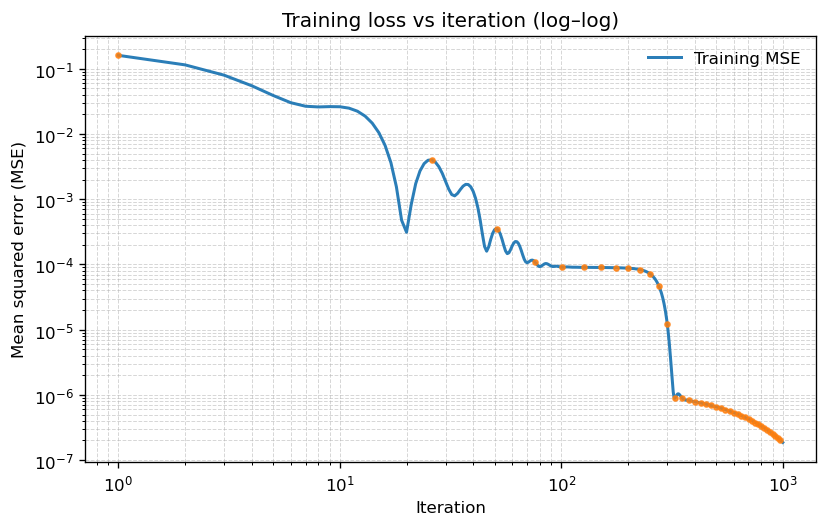

```
Initial loss: 1.602168e-01
Final loss: 1.867268e-07
Min loss: 1.867268e-07 (at iter 1000)
```

```python
# TODO: use matplotlib to plot the training loss
loss_arr = np.asarray([float(l) for l in losses])

fig, ax = plt.subplots(figsize=(7, 4.5), dpi=120)

x = np.arange(1, len(loss_arr) + 1)
ax.loglog(x, loss_arr, linewidth=1.8, alpha=0.95, label="Training MSE")
ax.loglog(x[::25], loss_arr[::25], marker="o", linestyle="None", markersize=3, alpha=0.8)

ax.set_title("Training loss vs iteration (log–log)")
ax.set_xlabel("Iteration")
ax.set_ylabel("Mean squared error (MSE)")

ax.grid(True, which="both", linestyle="--", linewidth=0.6, alpha=0.5)
ax.legend(frameon=False)
plt.tight_layout()
plt.show()

print(f"Initial loss: {loss_arr[0]:.6e}")
print(f"Final loss: {loss_arr[-1]:.6e}")
print(f"Min loss: {loss_arr.min():.6e} (at iter {loss_arr.argmin()+1})")
```

Answer the question in the box below:

1. How many iterations does it take to reach a loss of $10^{-3}$?
2. What final loss function value is obtained?
1. The loss of $10^{-3}$ is reached around 20 iterations in.
2. The final loss value found is 1.867268e-7.

### Testing the Model

There are 64 structures on the MP website containing only carbon - we only defined four of them. Many of them are very similar to each other, but some are completely different. Here is a search for them:

https://next-gen.materialsproject.org/materials?_limit=75&formula=C

I have saved the CIF files for 10 of these in the folder `MP_Carbon_CIFs` which should get downloaded with the assignment. They have a variety of different bonding: some all-covalent, some with covalent units and van der Waals interactions between layers or molecules.

The names of the structures, and their formation energy above the convex hull, are stored in the dictionary below.

One of them, C_2516584, is what has defined the "Convex Hull" for this stoichiometry: its formation energy is defined as zero, as it is the lowest observed value per atom of all the structures of this same composition.

```python
from ase.io import read
import numpy as np

# Strings for the files PBE - use these
test_structures = {"C_568363": 0.008,
                   "C_569416": 0.030,
                   "C_616440": 0.143,
                   "C_667273": 0.391,
                   "C_1008395": 0.335,
                   "C_1080826": 0.301,
                   "C_1096869": 0.118,
                   "C_1190171": 0.293,
                   "C_2516584": 0.000,
                   "C_2646980": 0.643,}

# Example of reading the first entry from a cif file, to return an ASE atoms object
test1_atoms = read("MP_Carbon_CIFs/C_568363.cif")

test_energies_ref = np.fromiter(test_structures.values(), dtype=float)
# Atoms object has .cell and .positions arrays inside it
cell = np.array(test1_atoms.cell)
positions = np.array(test1_atoms.positions)

# TODO: load all the cif files in this directory and
#       create a graph for each, in a list called test_graphs
# YOUR CODE HERE
graphs = []
for i, energy in test_structures.items():
    atoms = read(f"MP_Carbon_CIFs/{i}.cif")
    cell = np.array(atoms.cell)
    pos = np.array(atoms.positions)

    graph = create_graph(
        positions=pos,
        cell=cell,
        energy=energy,
        cutoff=cutoff
    )

    graphs.append(graph)
```

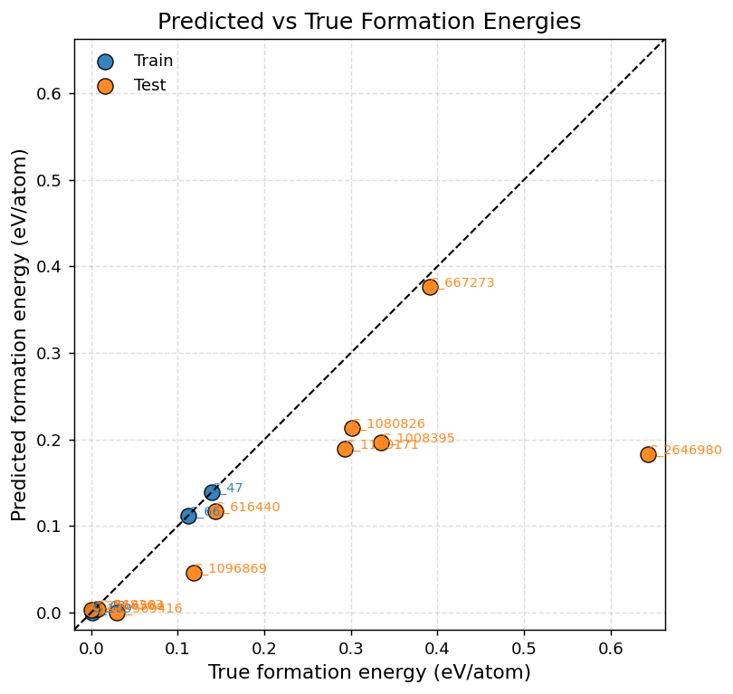

```python
# TODO: now create a batch of graphs for them, calling this test_dataset
# YOUR CODE HERE
test_dataset = jraph.batch(graphs)

# We then apply the model to this test batch
test_energies_pred = model.apply(params, test_dataset).array.squeeze(1)
# And to the training batch
train_energies_pred = model.apply(params, dataset).array.squeeze(1)

# Calculate mean absolute error of the predictions for the test set
mae_test = 0
# YOUR CODE HERE

test_target = test_dataset.globals["energies"]
train_target = dataset.globals["energies"]
mae_test = jnp.mean(jnp.abs(test_energies_pred - test_target))

# TODO: Plot a scatter plot to compare the predictions to the targets
# plot the training data in one colour and the test data in another
# Label the axes and include a dotted line at y=x for reference
# it would be helpful to add a label to each point with the id of the structure

train_target_np = np.asarray(train_target)
test_target_np = np.asarray(test_target)
train_pred_np = np.asarray(train_energies_pred)
test_pred_np = np.asarray(test_energies_pred)

# Create figure
fig, ax = plt.subplots(figsize=(7, 6), dpi=130)

# Scatter: training
ax.scatter(
    train_target_np,
    train_pred_np,
    s=90,
    color="tab:blue",
    edgecolor="black",
    linewidth=0.8,
    alpha=0.9,
    label="Train"
)

# Scatter: test
ax.scatter(
    test_target_np,
    test_pred_np,
    s=90,
    color="tab:orange",
    edgecolor="black",
    linewidth=0.8,
    alpha=0.9,
    label="Test"
)

# y = x reference line
all_vals = np.concatenate([train_target_np, test_target_np,
                           train_pred_np, test_pred_np])
lims = [all_vals.min() - 0.02, all_vals.max() + 0.02]

ax.plot(lims, lims, linestyle="--", color="black", linewidth=1.2)

# Equal axis scaling
ax.set_xlim(lims)
ax.set_ylim(lims)
ax.set_aspect("equal", adjustable="box")

# Labels
ax.set_xlabel("True formation energy (eV/atom)", fontsize=12)
ax.set_ylabel("Predicted formation energy (eV/atom)", fontsize=12)
ax.set_title("Predicted vs True Formation Energies", fontsize=14)

# Grid
ax.grid(True, linestyle="--", alpha=0.4)

# Annotate training points
train_ids = ["C_48", "C_66", "C_169", "C_47"]
for i, name in enumerate(train_ids):
    ax.text(
        train_target_np[i],
        train_pred_np[i],
        name,
        fontsize=8,
        color="tab:blue",
        alpha=0.9
    )

# Annotate test points
test_ids = list(test_structures.keys())
for i, name in enumerate(test_ids):
    ax.text(
        test_target_np[i],
        test_pred_np[i],
        name,
        fontsize=8,
        color="tab:orange",
        alpha=0.9
    )

ax.legend(frameon=False)
plt.tight_layout()
plt.show()
```

```python
# Test on test_errors is hidden
print('mae_test = ',mae_test)
```

```
mae_test =  0.09394702
```

```python
# Workspace for any visualisation and tests of which structures are well-represented and which are not producing good predictions
```

### Discuss the performance of the model

Under what conditions does it seem to be reliable as a predictor of the total energy?

For what kind of structures is it unreliable - do they have any common features?

The model is a reliable predictor of total energy when the true formation energy is low and the structures are similar to the training set. This is shown in the plot where the low formation energy test structures have strong predictive performance, so we can deduce that for (near) stable carbon allotropes, this model is suitable. For higher formation energy structures and more complex carbon allotropes, model performance degrades. For example, `C_2646980` is significantly underpredicted.

### How could we improve the performance of the model?

Consider possible changes to model structure, training procedure and the composition of the training set.

Feel free to perform and report and computational experiments you perform by changing the code above, but please reset it before submission to the suggested parameters.

- Increase the size of the training set and including more carbon structures with the full range of bonds (i.e. van der Waal-bound structures, chain motifs, $sp^2$ sheets, $sp^3$ networks, etc.). Variation should be prevalent throughout the dataset to help with robustness, mainly through reasonable pertubations in structure.
- The use of holdout layers to help generalisation.
- Regularisation to mitigate overfitting to the training data, through the use of weights, early stopping during validation, dropout layers.
- Varying learning rate (i.e. exponential decay).

## 4) Using the MACE_MP foundation model

#### NB: This section is an optional extra with a low weight in mark scheme (15% of the assignment, which is 15% of the module)

Like Nequip, MACE is a state-of-the-art Machine Learned Interatomic Potential, making use of e3nn to achieve data-efficientcy and high-accuracy. There are PyTorch and JAX versions available - the PyTorch version is under more active development at the present time so we will try that here.

https://github.com/ACEsuit/mace

The MACE architecture was first described in 2022, and its innovation was to combine successfully using Atomic Cluster Expansion techniques with Message Passing methods as in Graph Neural Networks.

In late 2023, the MACE team released two papers describing ["Foundation Models"](https://mace-docs.readthedocs.io/en/latest/examples/foundation_models.html): one [general-purpose organic force field](https://arxiv.org/abs/2312.15211), and one [model trained on the entire Materials Project database](https://arxiv.org/abs/2401.00096), for general purpose use on inorganic crystals.

We will try the latter, mace_mp. We will use ASE calculators here. These are quite slow to use in CPU mode, but we will not try them on anything very large here.

These sections are relatively "unstructured". You may have to look up [ASE syntax](https://wiki.fysik.dtu.dk/ase/) to complete them. They will require self-directed reading from the examples on the ASE website. I would prefer not to be dealing with questions about this section, as it is meant to be an opportunity to discover functionality of a package - not a hand-holding exercise! These sections are not heavily-weighted in the mark scheme (15% of the assignment), so if you do not have time to give them a try, you will not lose much.

Optimise the the atomic positions for `C_47` (at fixed cell size) using the [BFGS optimizer](https://wiki.fysik.dtu.dk/ase/ase/optimize.html#bfgs), until fmax=0.001 eV/Ang.

Compare it to that of the structure as in the MP database - does it find the same positions?

```python
from mace.calculators import mace_mp
from ase.optimize.bfgs import BFGS
from ase.io import read
from ase.visualize import view

f = "C_47"
atoms_ref = read(f"MP_Carbon_CIFs/{f}.cif")
atoms_opt = atoms_ref.copy()
calc = mace_mp(default_dtype="float64")

# TODO: geometry optimise the atoms_opt model
# YOUR CODE HERE
atoms_opt.calc = calc
opt = BFGS(atoms_opt, logfile="C_47_bfgs.log", trajectory="C_47_bfgs.traj")
opt.run(fmax=0.001)
```

```
cuequivariance or cuequivariance_torch is not available. Cuequivariance acceleration will be disabled.
Using medium MPA-0 model as default MACE-MP model, to use previous (before 3.10) default model please specify 'medium' as model argument
Downloading MACE model from 'https://github.com/ACEsuit/mace-mp/releases/download/mace_mpa_0/mace-mpa-0-medium.model'
Cached MACE model to /home/jovyan/.cache/mace/macempa0mediummodel
Using Materials Project MACE for MACECalculator with /home/jovyan/.cache/mace/macempa0mediummodel
Using float64 for MACECalculator, which is slower but more accurate. Recommended for geometry optimization.
```

```
Using head default out of ['default']
```

```
np.True_
```

```python
print(atoms_ref.positions[0])
print(atoms_opt.positions[0])
print(atoms_ref.positions[0]-atoms_opt.positions[0])
from ase.visualize import view

view(atoms_ref+atoms_opt,viewer='ngl')
```

```
[-1.25165138e-08  1.44528256e+00  2.61833545e-01]
[-6.29288995e-10  1.44528256e+00  2.64462684e-01]
[-1.18872248e-08  6.86309254e-09 -2.62913847e-03]
```

```
HBox(children=(NGLWidget(), VBox(children=(Dropdown(description='Show', options=('All', 'C'), value='All'), Dr…
```

Starting from the geometry you optimised, plot the [phonon band structure](https://wiki.fysik.dtu.dk/ase/ase/phonons.html#module-ase.phonons) for 100 points along the path $\Gamma-K-M-\Gamma$ for C_2516584, on a 2x2x1 supercell.

You will need `atoms.cell.bandpath` and `get_band_structure` from `Phonons()`. The resulting `bs` object has its own `bs.plot` routine which can handle the plotting (you need to set `emin` and `emax` to get it to plot a sensible range).

The run will take a while - if you interrupt it you may find a `phonon` directory that you will need to delete (`rm -rf phonon`)

If your phonon calculation works out correctly, you should find phonon frequencies in the range 0 to about 0.16 eV - with some negative frequencies actually corresponding to imaginary modes, which represent instabilities.

[output not shown]

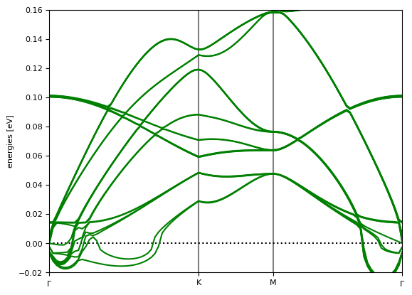

```python
from ase.phonons import Phonons

atoms = read("MP_Carbon_CIFs/C_2516584.cif")
atoms.calc = calc

phonons = Phonons(atoms, atoms.calc, supercell=(2, 2, 1), name="phonon")
phonons.run()
phonons.read(acoustic=True)

band_path = atoms.cell.bandpath("GKMG", npoints=100)
band_structure = phonons.get_band_structure(band_path)

fig = band_structure.plot(emin=-0.02, emax=0.16)
```

[Initialise the velocities](https://wiki.fysik.dtu.dk/ase/ase/md.html#ase.md.velocitydistribution.MaxwellBoltzmannDistribution) of the C_1008395 model to a Maxwell Boltzmann distribution at 300K, then run [Molecular Dynamics](https://wiki.fysik.dtu.dk/ase/tutorials/md/md.html) for 100 timesteps with the [Langevin Thermostat](https://wiki.fysik.dtu.dk/ase/ase/md.html#module-ase.md.langevin) using T=300K, friction=0.01/fs, timestep 2 fs.

Print the initial and final coordinates.

```python
from ase.md.langevin import Langevin
from ase.md.velocitydistribution import MaxwellBoltzmannDistribution
from ase import units

f = "C_1008395"
atoms_ref = read(f"MP_Carbon_CIFs/{f}.cif")
atoms_md = atoms_ref.copy()
MaxwellBoltzmannDistribution(atoms_md, temperature_K=300)

atoms_md.calc = calc
init = atoms_md.get_positions().copy()
print(f"First 5 atoms coordinates: {init[:5]}")

lang_dynamics = Langevin(
    atoms_md, timestep=2.0 * units.fs, temperature_K=300, friction=0.01/units.fs
)

lang_dynamics.run(100)
final_coords = atoms_md.get_positions().copy()
print(f"Final coordinates for the first 5 atoms: {final_coords[:5]}")
# we can quantify drift by taking the norm
displacement = np.linalg.norm(final_coords - init, axis=1)
print(f"Mean displacement: {displacement.mean()}")
```

```
First 5 atoms coordinates: [[0.78457074 0.78457074 0.        ]
 [1.39216209 1.39216209 1.24800197]
 [2.96130357 1.39216209 1.24800197]
 [3.56889492 0.78457074 0.        ]
 [2.96130357 2.96130357 1.24800197]]
Final coordinates for the first 5 atoms: [[0.65731707 0.74368591 0.25325471]
 [1.24992728 1.3337019  1.52495348]
 [2.81391474 1.33351466 1.50312553]
 [3.4488729  0.76215883 0.20988165]
 [2.90817547 2.90365059 1.45309954]]
Mean displacement: 0.2784179693352623
```

```python
# View final coordinates overlaid with initial coordinates - has the model drifted?
view(atoms_ref+atoms_md,viewer='ngl')
```

```
HBox(children=(NGLWidget(), VBox(children=(Dropdown(description='Show', options=('All', 'C'), value='All'), Dr…
```

## 5) Summary

You have had an opportunity to set up the internal components of a Graph Neural Network making use of Euclidean symmetry. We trained the model on a very small dataset of Carbon Allotropes and showed it could be reasonably predictive of the energy of other Carbon Allotropes.

We also tried the MACE MP foundation model, and showed that it could handle simulation tasks similar to the models you tried. We showed how the Atomic Simulation Environment could be used to handle a variety of simple simulation workflows with a Machine Learned Interatomic Potential.